# 707 Data Processing

Sofia Pozsonyiova

11/2/2022

# Data Creation

```r
# Libraries
library(dplyr)
```

```r
library(DataExplorer)
library(ggplot2)
```

## Reading in / Saving

```r
# Reading in Data and Saving Out

# dat <- read.csv("/Users/sofiapozsonyiova/Downloads/PubR2019-race\ no\ county\ csv/PubR2019-race\ no\ county.csv")
# save(dat, file ="/Users/sofiapozsonyiova/Downloads/FullDataSet.RData")
# save(dat_sub_named,file = "/Users/sofiapozsonyiova/Documents/GitHub/Private707/data/SubsetDat.RData")
```

```r
# Loading Data in
setwd("/Users/sofiapozsonyiova/Downloads/")
load("SubsetDat.RData")
```

## Subsetting

```r
# Extracting variables of interest based off of domain knowledge
dat_sub_named <- dat_sub %>% dplyr::select(P1,P2,Biosex,P5,P8,P11:P14a,P14ab1:P14ab14,P15:P17c,P18b:P18d,P20a:P20c,P20f:P22a,P22e,P23c,P23e,P25:P26h,P27b,P27c,P27e:P29e,P30:P39a,P40d,P41b:P41e,P41g:P42d,P45,P47a:P47e,P49d,P49a,P49c:P50d,P52a:P52c,P54a:P54b,P56a:P56c,P58a:P58c,P59:P66,P70a,P70c:P70d,P71a:P71d,P74,P76,P80c:P80g,P80i:P81,P86,FiveFV,Binge,Region) %>% mutate(SelfPerceivedHealth = as.factor(P28))
```

```r
# Setting variables to be factors
col_names <- names(dat_sub_named)
dat_sub_named[,col_names] <- lapply(dat_sub_named[,col_names] , factor)

# QC:
# str(dat_sub_named)
```

## Exploratory Analysis

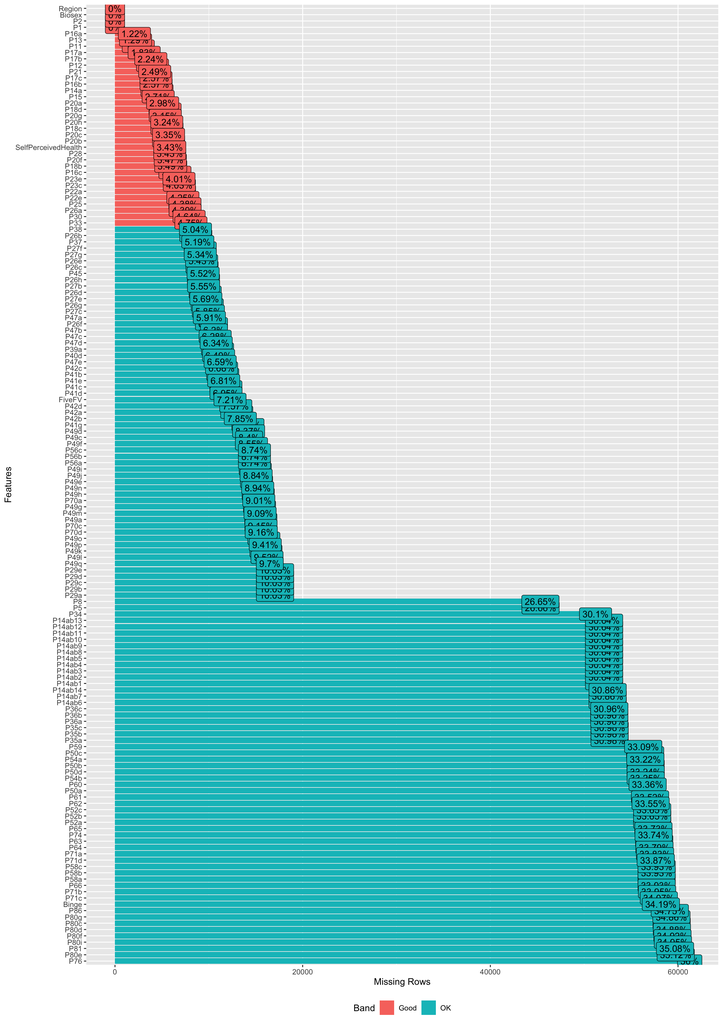

```r
# Visualizing Missing
plot_missing(dat_sub_named)
```

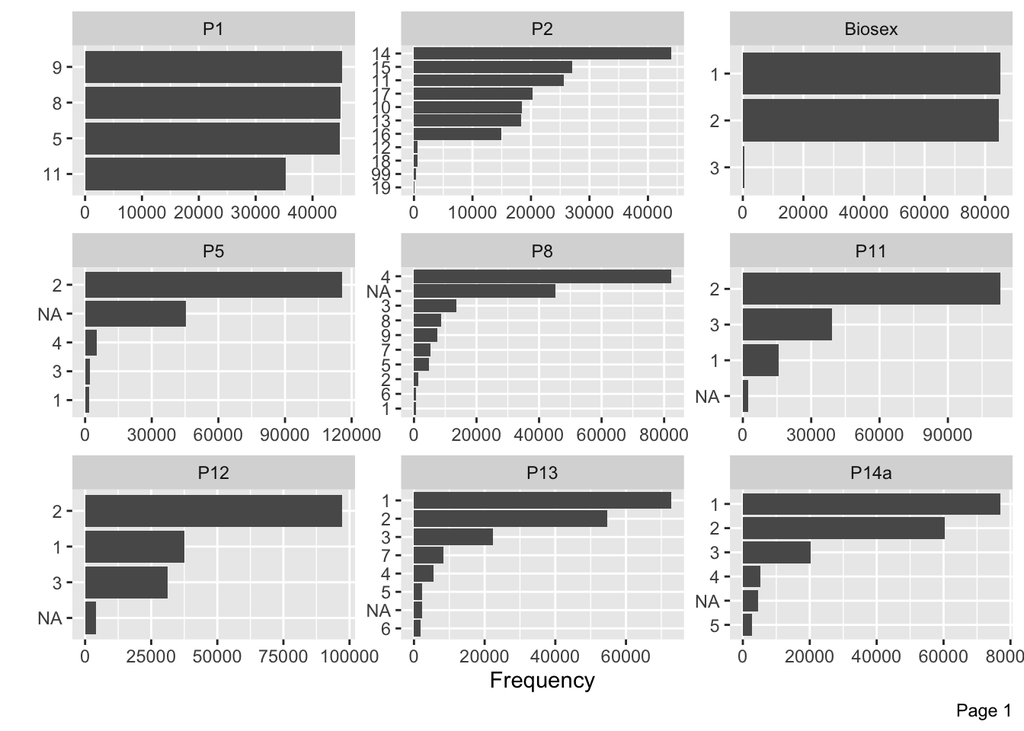

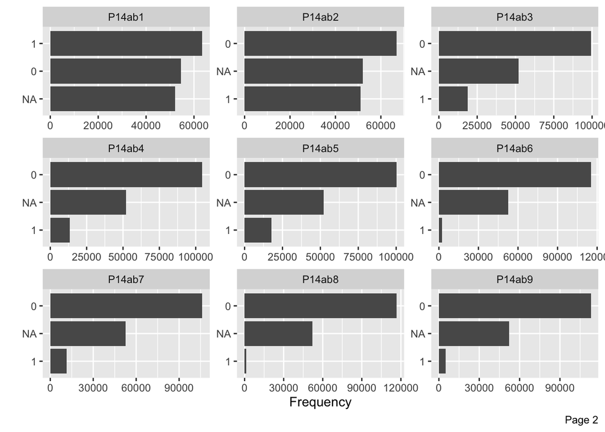

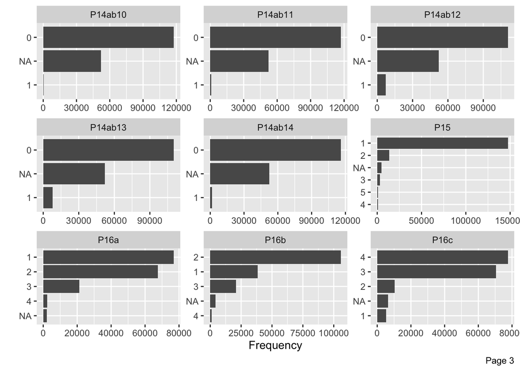

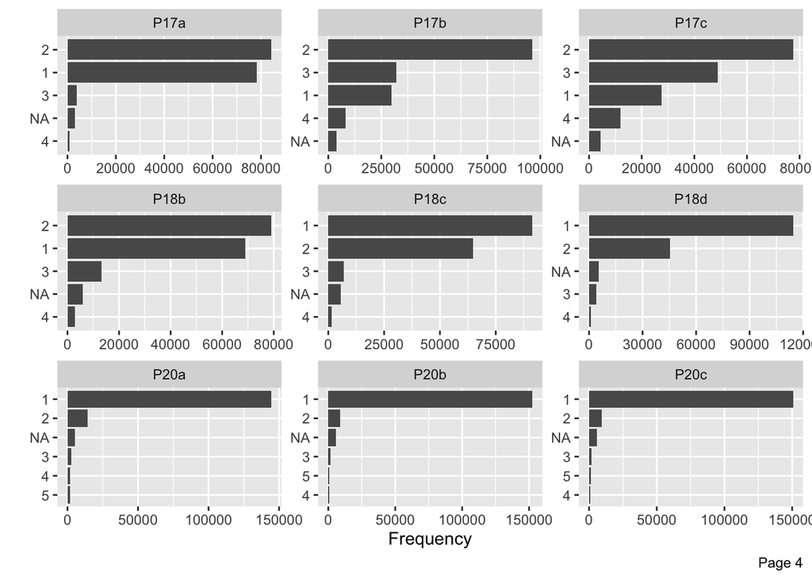

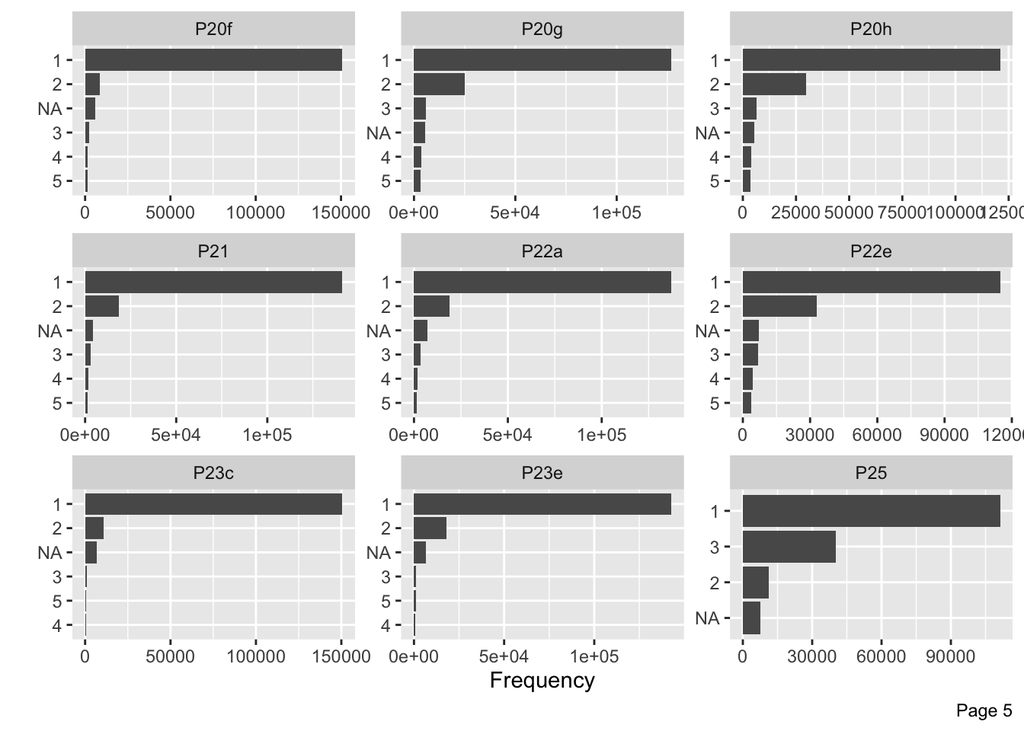

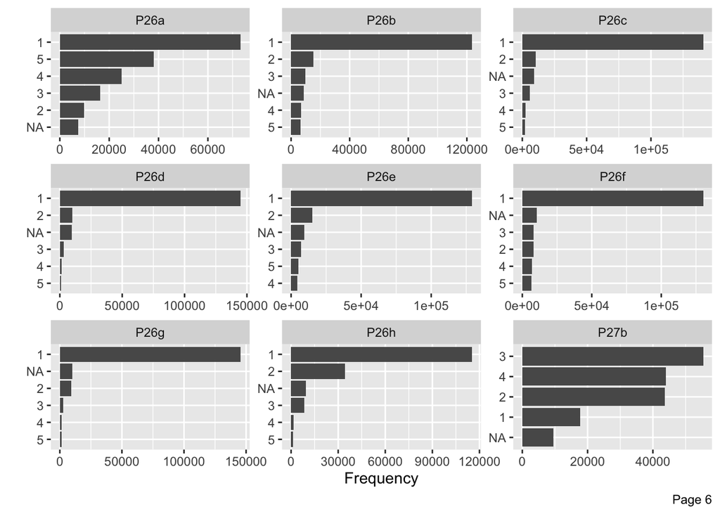

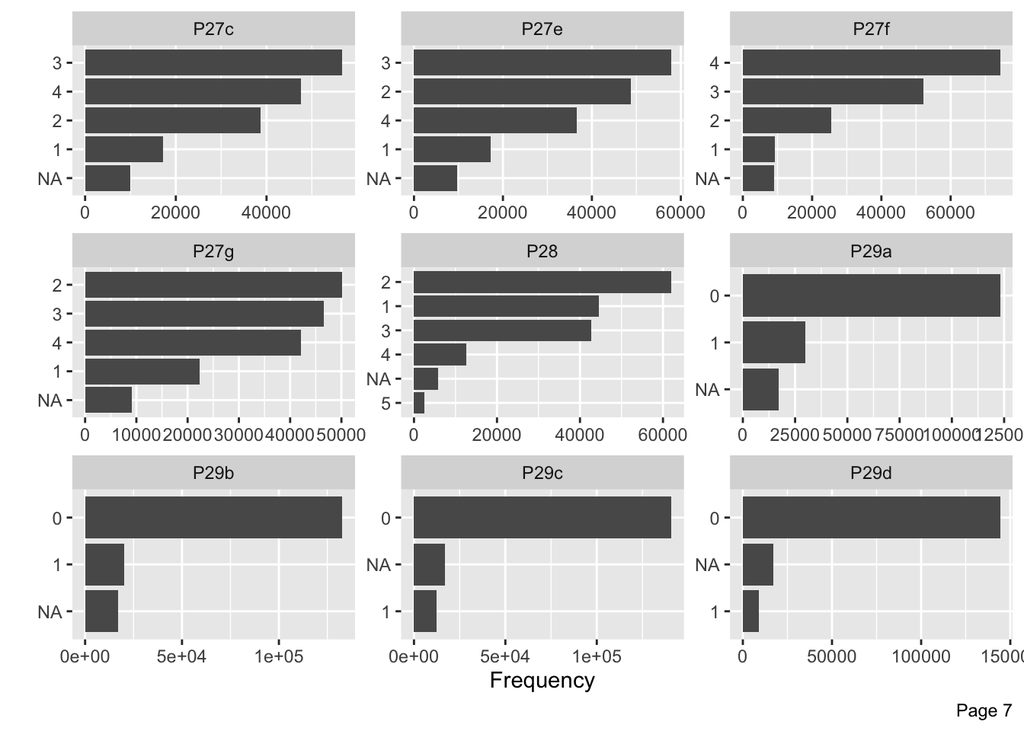

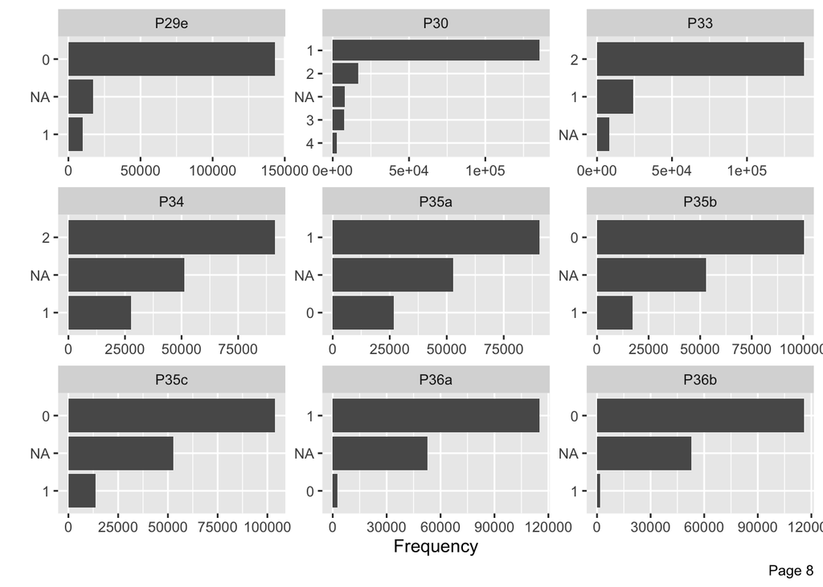

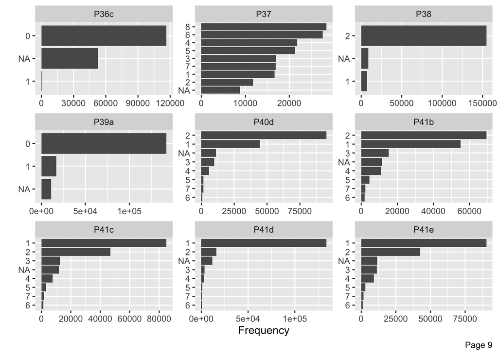

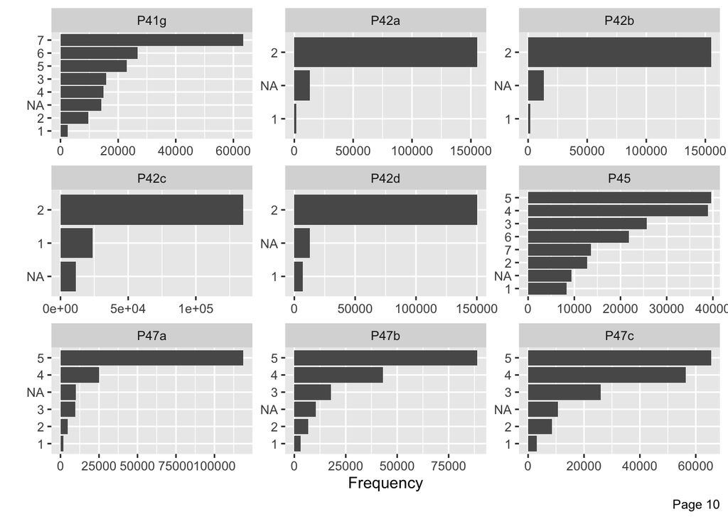

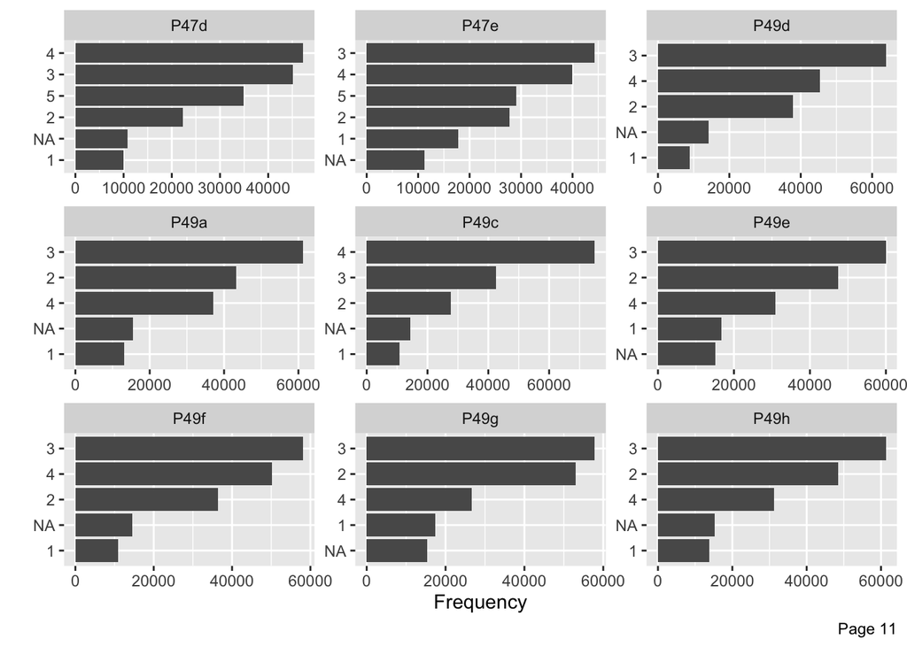

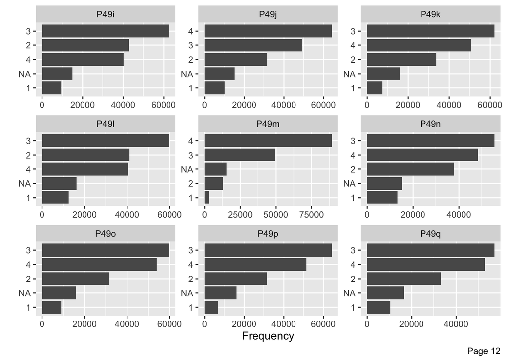

[5 more figures not shown]

```r
# Visualizing Each Distribution
plot_bar(dat_sub_named)
```

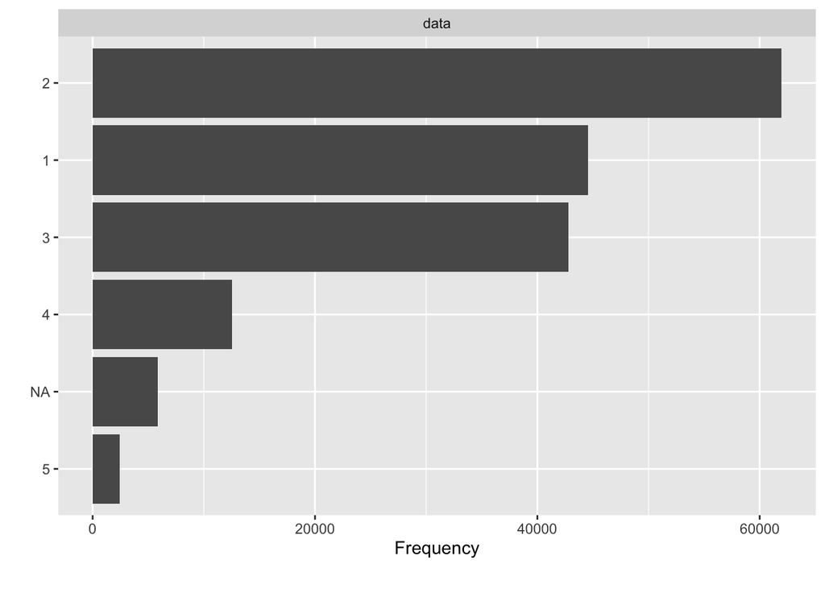

```r
# Comparing outcome variable if all na removed
na_removed_dat <- na.omit(dat_sub_named)
full_dat <- dat_sub_named

# Comparing counts visually
plot_bar(full_dat$SelfPerceivedHealth)
```

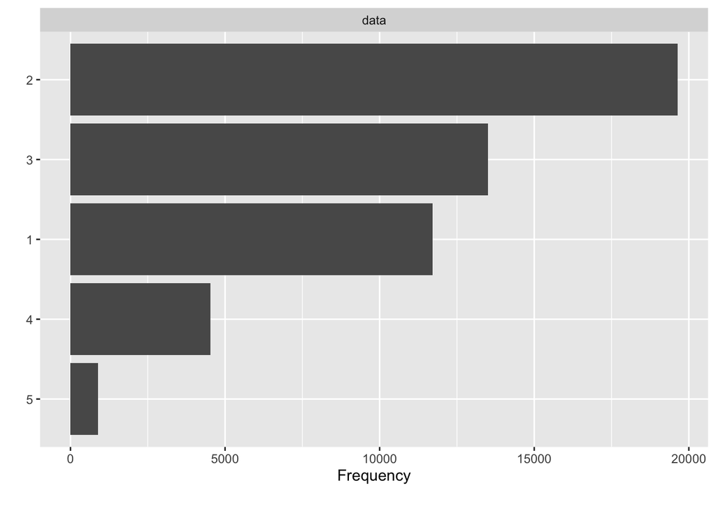

```r
plot_bar(na_removed_dat$SelfPerceivedHealth)
```

```r
# Checking Proportions within outcome variable numerically
na_removed_dat %>%
  group_by(SelfPerceivedHealth) %>%
  summarise(cnt = n()) %>%
  mutate(freq = round(cnt / sum(cnt), 3)) %>%
  arrange(desc(freq))
```

```
## # A tibble: 5 × 3
##   SelfPerceivedHealth   cnt  freq
##   <fct>               <int> <dbl>
## 1 2                   19645 0.391
## 2 3                   13506 0.269
## 3 1                   11714 0.233
## 4 4                    4528 0.09
## 5 5                     884 0.018
```

```r
full_dat %>%
  group_by(SelfPerceivedHealth) %>%
  summarise(cnt = n()) %>%
  mutate(freq = round(cnt / sum(cnt), 3)) %>%
  arrange(desc(freq))
```

```
## # A tibble: 6 × 3
##   SelfPerceivedHealth   cnt  freq
##   <fct>               <int> <dbl>
## 1 2                   61968 0.364
## 2 1                   44576 0.262
## 3 3                   42768 0.251
## 4 4                   12547 0.074
## 5 <NA>                 5838 0.034
## 6 5                    2431 0.014
```

```r
# QC:
# Proportions:
#    n     prop.full prop.red
# 1 44576     0.262       0.233
# 2 61968     0.364       0.391
# 3 42768     0.251       0.269
# 4 12547     0.074       0.090
# 5 2431    0.014       0.018
```

## Combining/Redefining Variables

SelfPerceivedHealth (P28):  
0 = Great Health 1 = Poor or Fair Health

```r
na_removed_dat <- na_removed_dat %>% mutate(SelfPerceivedHealth = ifelse(SelfPerceivedHealth == 1 |SelfPerceivedHealth == 2, 0,           ifelse(SelfPerceivedHealth == 3 |SelfPerceivedHealth == 4 | SelfPerceivedHealth == 5,1,NA))) %>% dplyr::select(-P28)
```

```r
# QC:
# na_removed_dat %>%
#   group_by(SelfPerceivedHealth) %>%
#   summarise(cnt = n()) %>%
#   mutate(freq = round(cnt / sum(cnt), 3)) %>%
#   arrange(desc(freq))
```

Diabetes (P42a) or Pre-Diabetes (P42b) 0 = No 1 = Yes

```r
na_removed_dat <- na_removed_dat %>% mutate(Diab_Prediab = ifelse(P42a == 1 | P42b == 1,1,
ifelse(P42a == 2 | P42b == 2,0,NA))) %>% dplyr::select(-c(P42a,P42b))
```

```r
# QC:
# na_removed_dat %>%
#   group_by(Diab_Prediab) %>%
#   summarise(cnt = n()) %>%
#   mutate(freq = round(cnt / sum(cnt), 3)) %>%
#   arrange(desc(freq))
```

Abusive Relationship P54a:Have you been in a casual or serious relationship where your partner ever physically hurt you on purpose? P54b: Have you been in a casual or serious relationship where your partner ever verbally hurt or controlled you? 0 = No 1 = Yes

```r
na_removed_dat <- na_removed_dat %>% mutate(AbuseRelationship = ifelse(P54a == 1 | P54b == 1,1,
ifelse(P54a == 2 | P54b == 2,0,NA))) %>% dplyr::select(-c(P54a,P54b))
```

```r
# QC:
# na_removed_dat %>%
#   group_by(AbuseRelationship) %>%
#   summarise(cnt = n()) %>%
#   mutate(freq = round(cnt / sum(cnt), 3)) %>%
#   arrange(desc(freq))
```

Foster Care P56a, Have you ever been in foster care? No P56b,Have you ever been in foster care? Yes, during the last year P56c,Have you ever been in foster care? Yes, more than a year ago 0 = No 1 = Yes

```r
na_removed_dat <- na_removed_dat %>% mutate(FosterCare = ifelse(P56a == 1 & (P56b == 0 | P56c == 0),0,
ifelse(P56a == 0 & (P56b == 1 | P56c == 1),1,NA))) %>% dplyr::select(-c(P56a,P56b,P56c))
```

```r
# QC:
# na_removed_dat %>%
#   group_by(FosterCare) %>%
#   summarise(cnt = n()) %>%
#   mutate(freq = round(cnt / sum(cnt), 3)) %>%
#   arrange(desc(freq))
```

Drug Frequency P80c 263 During the last 12 months, on how many occasions (if any) have you used MDMA (E, X, ecstasy, Molly), GHB (G, Liquid E, Liquid X, roofies) or Ketamine (Special K)? P80d 264 During the last 12 months, on how many occasions (if any) have you used crack, coke or cocaine in any form? P80e 265 During the last 12 months, on how many occasions (if any) have you used heroin (smack, junk, China White)? P80f 266 During the last 12 months, on how many occasions (if any) have you used methamphetamine (meth, glass, crank, crystal meth, ice)? P80g 267 During the last 12 months, on how many occasions (if any) have you used over-the-counter drugs such as cough syrup, cold medicine or diet pills that you took only to get high? P80i 269 During the last 12 months, on how many occasions (if any) have you used any other synthetic drugs such as bath salts (Ivory Wave, White Lightning) that you took only to get high? 1 = 0 days 2 = 1 to 2 days 3 = 3 to 5 days 4 = 6 to 9 days 5 = 10 to 19 days 6 = 20 or more

```r
na_removed_dat <- na_removed_dat %>% mutate(DrugFreq = ifelse(P80c == 1 | P80d == 1 | P80e == 1 | P80f == 1 |P80g == 1 |P80i == 1,0,
 ifelse(P80c != 1 | P80d != 1 | P80e != 1 | P80f != 1 |P80g != 1 |P80i != 1,1,NA))) %>% dplyr::select(-c(P80c,P80d,P80e,P80f,P80g,P80i))
```

```r
# QC:
# check <- dat_sub_named%>% na.omit() %>% dplyr::select(P80c,P80d,P80e,P80f,P80g,P80i)
# check %>% group_by(P80c) %>% summarise(cnt = n()) %>% mutate(freq = round(cnt / sum(cnt), 3)) %>%  arrange(desc(freq))

# na_removed_dat %>%
#   group_by(DrugFreq) %>%
#   summarise(cnt = n()) %>%
#   mutate(freq = round(cnt / sum(cnt), 3)) %>%
#   arrange(desc(freq))
```

AlcDrug_Residence P59 Do you live with anyone who drinks too much alcohol? P60 Do you live with anyone who uses illegal drugs or abuses prescription drugs? 0 = No 1 = Yes

```r
na_removed_dat <- na_removed_dat %>% mutate(AlcDrug_Residence = ifelse(P59 == 1 | P60 == 1,1,
ifelse(P59 == 2 | P60 == 2,0,NA))) %>% dplyr::select(-c(P59,P60))
```

```r
# QC:
# check <- dat_sub_named %>% na.omit() %>% dplyr::select(P59,P60)
# check %>% group_by(P59) %>% summarise(cnt = n()) %>% mutate(freq = round(cnt / sum(cnt), 3)) %>%  arrange(desc(freq))
# check %>% group_by(P60) %>% summarise(cnt = n()) %>% mutate(freq = round(cnt / sum(cnt), 3)) %>%  arrange(desc(freq))
#
# na_removed_dat %>%
#   group_by(AlcDrug_Residence) %>%
#   summarise(cnt = n()) %>%
#   mutate(freq = round(cnt / sum(cnt), 3)) %>%
#   arrange(desc(freq))
```

Nicotine Freq P71a During the last 30 days, on how many days did you smoke a cigarette? P71b During the last 30 days, on how many days did you smoke cigars, cigarillos or little cigars? P71c During the last 30 days, on how many days did you use chewing tobacco, snuff or dip? 1 = 0 days 2 = 1 to 2 days 3 = 3 to 9 days 4 = 10 to 19 days 5 = 20 to 29 days 6 = All 30 days

In the last 30 days have you used any nicotine (not including vape)? 0 = No 1 = Yes

```r
na_removed_dat <- na_removed_dat %>% mutate(NicFreq = ifelse(P71a == 1| P71b == 1| P71c == 1,0,
ifelse(P71a != 1| P71b != 1| P71c != 1,1,NA))) %>% dplyr::select(-c(P71a,P71b,P71c))
```

```r
# QC:
# check <- dat_sub_named %>% na.omit() %>% dplyr::select(P71a,P71b,P71c)
# check %>% group_by(P71a) %>% summarise(cnt = n()) %>% mutate(freq = round(cnt / sum(cnt), 3)) %>%  arrange(desc(freq))
# check %>% group_by(P71b) %>% summarise(cnt = n()) %>% mutate(freq = round(cnt / sum(cnt), 3)) %>%  arrange(desc(freq))
# check %>% group_by(P71c) %>% summarise(cnt = n()) %>% mutate(freq = round(cnt / sum(cnt), 3)) %>%  arrange(desc(freq))

# na_removed_dat %>%
#   group_by(NicFreq) %>%
#   summarise(cnt = n()) %>%
#   mutate(freq = round(cnt / sum(cnt), 3)) %>%
#   arrange(desc(freq))
```

Imprisoned Parent/Guardian P58a Have any of your parents or guardians ever been in jail or prison? None of my parents or guardians has ever been in jail or prison P58b Have any of your parents or guardians ever been in jail or prison? Yes, I have a parent or guardian in jail or prison right now P58c Have any of your parents or guardians ever been in jail or prison? Yes, I have had a parent or guardian in jail or prison in the past 0 = No 1 = Yes

```r
na_removed_dat <- na_removed_dat %>% mutate(ImprisGaurd = ifelse(P58a == 1 & (P58b == 0 | P58c == 0),0,
ifelse(P58a == 0 & (P58b == 1 | P58c == 1),1,NA))) %>% dplyr::select(-c(P58a,P58b,P58c))
```

```r
# QC:
# check <- dat_sub_named %>% na.omit() %>% dplyr::select(P58a,P58b,P58c)
# check %>% group_by(P58a) %>% summarise(cnt = n()) %>% mutate(freq = round(cnt / sum(cnt), 3)) %>%  arrange(desc(freq))
# check %>% group_by(P58b) %>% summarise(cnt = n()) %>% mutate(freq = round(cnt / sum(cnt), 3)) %>%  arrange(desc(freq))
# check %>% group_by(P58c) %>% summarise(cnt = n()) %>% mutate(freq = round(cnt / sum(cnt), 3)) %>%  arrange(desc(freq))
#
# na_removed_dat %>%
#   group_by(ImprisGaurd) %>%
#   summarise(cnt = n()) %>%
#   mutate(freq = round(cnt / sum(cnt), 3)) %>%
#   arrange(desc(freq))
```

Dental Issues: " Do you have any dental problems?" P29a Have you had any of the following dental problems during the past 12 months? Toothaches or pain P29b Have you had any of the following dental problems during the past 12 months? Decayed teeth or cavities P29c Have you had any of the following dental problems during the past 12 months? Swollen, painful or bleeding gums P29d Have you had any of the following dental problems during the past 12 months? Could not eat certain foods because of a dental problem

0 = No  
1 = Yes

```r
na_removed_dat <- na_removed_dat %>% mutate(DentalIssues = ifelse(P29a == 0 | P29b == 0|P29c == 0| P29d == 0,0,
ifelse(P29a == 1| P29b == 1|P29c == 1| P29d == 1,1,NA))) %>% dplyr::select(-c(P29a:P29e))
```

```r
# QC:
# check <- dat_sub_named %>% na.omit() %>% dplyr::select(P29a:P29f)
# check %>% group_by(P29a) %>% summarise(cnt = n()) %>% mutate(freq = round(cnt / sum(cnt), 3)) %>%  arrange(desc(freq))
# check %>% group_by(P29b) %>% summarise(cnt = n()) %>% mutate(freq = round(cnt / sum(cnt), 3)) %>%  arrange(desc(freq))
# check %>% group_by(P29b) %>% summarise(cnt = n()) %>% mutate(freq = round(cnt / sum(cnt), 3)) %>%  arrange(desc(freq))
# check %>% group_by(P29d) %>% summarise(cnt = n()) %>% mutate(freq = round(cnt / sum(cnt), 3)) %>%  arrange(desc(freq))
# check %>% group_by(P29e) %>% summarise(cnt = n()) %>% mutate(freq = round(cnt / sum(cnt), 3)) %>%  arrange(desc(freq))
#
# na_removed_dat %>%
#   group_by(DentalIssues) %>%
#   summarise(cnt = n()) %>%
#   mutate(freq = round(cnt / sum(cnt), 3)) %>%
#   arrange(desc(freq))
```

Mental Health Self Have you ever been treated for a mental health, emotional or behavioral problem? P35a Have you ever been treated for a mental health, emotional or behavioral problem? No P35b Have you ever been treated for a mental health, emotional or behavioral problem? Yes, during the last year P35c Have you ever been treated for a mental health, emotional or behavioral problem? Yes, more than a year ago 0 = No 1 = Yes

```r
na_removed_dat <- na_removed_dat %>% mutate(MentalHealthSelf = ifelse(P35a == 1 & (P35b == 0 | P35c == 0),0,
ifelse(P35a == 0 & (P35b == 1 | P35c == 1),1,NA))) %>% dplyr::select(-c(P35a,P35b,P35c))
```

```r
# QC:
# check <- dat_sub_named %>% na.omit() %>% dplyr::select(P35a:P35c)
# check %>% group_by(P35a) %>% summarise(cnt = n()) %>% mutate(freq = round(cnt / sum(cnt), 3)) %>%  arrange(desc(freq))
# check %>% group_by(P35b) %>% summarise(cnt = n()) %>% mutate(freq = round(cnt / sum(cnt), 3)) %>%  arrange(desc(freq))
# check %>% group_by(P35c) %>% summarise(cnt = n()) %>% mutate(freq = round(cnt / sum(cnt), 3)) %>%  arrange(desc(freq))
#
# na_removed_dat %>%
#   group_by(MentalHealthSelf) %>%
#   summarise(cnt = n()) %>%
#   mutate(freq = round(cnt / sum(cnt), 3)) %>%
#   arrange(desc(freq))
```

Drug/Alcohol Self Have you ever been treated for a drug or alcohol problem? P36a Have you ever been treated for an alcohol or drug problem? No P36b Have you ever been treated for an alcohol or drug problem? Yes, during the last year P36c Have you ever been treated for an alcohol or drug problem? Yes, more than a year ago 0 = No 1 = Yes

```r
na_removed_dat <- na_removed_dat %>% mutate(AlcDrugSelf = ifelse(P36a == 1 & (P36b == 0 | P36c == 0),0,
ifelse(P36a == 0 & (P36b == 1 | P36c == 1),1,NA))) %>% dplyr::select(-c(P36a,P36b,P36c))
```

```r
# QC:
# check <- dat_sub_named %>% na.omit() %>% dplyr::select(P36a:P36c)
# check %>% group_by(P36a) %>% summarise(cnt = n()) %>% mutate(freq = round(cnt / sum(cnt), 3)) %>%  arrange(desc(freq))
# check %>% group_by(P36b) %>% summarise(cnt = n()) %>% mutate(freq = round(cnt / sum(cnt), 3)) %>%  arrange(desc(freq))
# check %>% group_by(P36c) %>% summarise(cnt = n()) %>% mutate(freq = round(cnt / sum(cnt), 3)) %>%  arrange(desc(freq))
#
# na_removed_dat %>%
#   group_by(AlcDrugSelf) %>%
#   summarise(cnt = n()) %>%
#   mutate(freq = round(cnt / sum(cnt), 3)) %>%
#   arrange(desc(freq))
```

Suicide P52a Have you ever seriously considered attempting suicide? No P52b Have you ever seriously considered attempting suicide? Yes, during the last year P52c Have you ever seriously considered attempting suicide? Yes, more than a year ago

```r
na_removed_dat <- na_removed_dat %>% mutate(Suicide = ifelse(P52a == 1 & (P52b == 0 | P52c == 0),0, ifelse(P52a == 0 & (P52b == 1 | P52c == 1),1,NA))) %>% dplyr::select(-c(P52a,P52b,P52c))
```

```r
# QC:
# na_removed_dat %>%
#   group_by(Suicide) %>%
#   summarise(cnt = n()) %>%
#   mutate(freq = round(cnt / sum(cnt), 3)) %>%
#   arrange(desc(freq))
```

### Re-analyzing Subset Data

```r
cat <- na_removed_dat %>% dplyr::select(-(P2))
col_names <- names(na_removed_dat)
na_removed_dat[,col_names] <- lapply(na_removed_dat[,col_names] , factor)
# QC:
# str(na_removed_dat)
```

## Splitting Data

```r
set.seed(707)
sample <- sample(c(TRUE, FALSE), nrow(na_removed_dat), replace=TRUE, prob=c(0.8,0.2))
```

### Validation

n = 10,000

```r
validation_test <- na_removed_dat[!sample, ]
```

### Training

```r
ModelDev  <- na_removed_dat[sample, ]
#sample2 <- sample(c(TRUE, FALSE), nrow(ModelDev), replace=TRUE, prob=c(0.63,0.37))
sample2 <- sample(c(TRUE, FALSE), nrow(ModelDev), replace=TRUE, prob=c(0.70,0.30))
```

```r
Train <- ModelDev[sample2, ]
```

### Testing

```r
Test <- ModelDev[!sample2, ]
```

### Saving out

```r
save(validation_test,file = "/Users/sofiapozsonyiova/Documents/GitHub/Private707/data/ValidationTest.RData")
save(Train,file ="/Users/sofiapozsonyiova/Documents/GitHub/Private707/data/ModelDev_Train.RData")
save(Test,file ="/Users/sofiapozsonyiova/Documents/GitHub/Private707/data/ModelDev_Test.RData")
```